# How Does Climate Change Exacerbate Toxin Accumulation in Southern Resident Killer Whale Populations?

Population Modeling Proposal

2026-03-02

# 1 Introduction

Southern Resident Killer Whales (SRKWs; *Orcinus orca*) are a critically endangered population of approximately 73 individuals restricted to the inland waters of the Pacific Northwest. Despite decades of federal protection under the U.S. Endangered Species Act and Canada’s Species at Risk Act, the population has continued to decline, fewer than 74 individuals as of 2024. The three stressors for decreasing population include insufficient Chinook salmon prey, elevated persistent organic pollutants (POPs), and vessel noise (Williams et al., 2024). Among these, the interaction between prey scarcity and contaminant burden has received growing scientific attention, yet remains poorly captured by existing models.

Polychlorinated biphenyls (PCBs) are lipophilic organochlorines that accumulate up the food chain and reach peak concentrations in apex predators. Male SRKWs carry average blubber PCB loads of ~45,000 ng/g lipid weight, levels that exceed health-effects thresholds documented in harbor seals (Mongillo et al., 2016). PCBs impair reproductive function, suppress immune response, and can cause endocrine disruption, neurological damage, and cancer. When whales enter negative energy balance due to prey scarcity, blubber lipid reserves are mobilized, releasing stored PCBs directly into circulation and dramatically amplifying internal exposure (Marine Mammal Commission, 2020; Desforges et al., 2018).

Climate change operates as a force multiplier on this mechanism. Chinook salmon, the main prey of SRKWs are highly vulnerable to ocean warming. Life-cycle models project that Snake River spring/summer Chinook populations will decline rapidly under RCP 4.5 and RCP 8.5 scenarios, driven by rising sea surface temperatures and degraded freshwater habitat, with the largest populations facing high extinction risk by the 2060s (Crozier et al., 2021). As prey declines, it causes their bodies to break down stored fat more regularly and more intensely, which can release harmful stored pollutants into their system. Climate change doesn’t just cut down on their food supply, it also triggers the release of harmful toxins that these killer whales have stored in their fat for years. When prey gets scarcer and they go hungry more often, their bodies burn that fat, unlocking and dumping those old pollutants into their bloodstream. This creates a vicious cycle that speeds up the population’s decline.

The main research question for this project is: How does climate-driven prey decline alter the rate and magnitude of PCB accumulation in SRKW life stages, and what are the downstream consequences for population viability? I tackle this question with a stage-structured stochastic population model. This type of model tracks different age/life stages of the whales (like calves, juveniles, adults) and includes random variation to make predictions more realistic. In the model, the whales’ key life events—such as survival rates and reproduction—are directly linked to a separate “toxin sub-model.” That sub-model is then used in various climate change scenarios to predict future prey availability (Chinook salmon). This allows me to measure exactly how much climate change speeds up toxin buildup through the mobilization pathway: When prey is scarce, the whales fast more often and burn stored fat (blubber) for energy. This releases PCBs that were locked away in the fat into their bloodstream, adding extra exposure on top of what they get just from eating contaminated prey. The result? Toxin levels rise faster and higher than if only normal dietary intake were involved, creating a harmful feedback loop that worsens health, reproduction, and overall population decline.

# 2 Model Description

## 2.1 Stage-Structured Demographic Framework

The population is modeled as a stage-structured matrix model with *n* = 4 biologically distinct life stages: (1) calves (0–2 yr), (2) juveniles (2–10 yr), (3) reproductive females (10–42 yr), and (4) post-reproductive individuals (>42 yr). This staging reflects SRKW life history as documented in long-term photo-identification records (Olesiuk et al., 1990; Ford et al., 2010). The population state vector at time *t* is:

$$\mathbf{N}(t) = [N_1(t),\ N_2(t),\
N_3(t),\ N_4(t)]^\top$$

$$\mathbf{N}(t+1) = \mathbf{A}(t) \cdot
\mathbf{N}(t)$$

where **A**(*t*) is the annual projection matrix containing survival probabilities ($\sigma_i$), stage-transition probabilities ($\gamma_i$), and fecundity ($F_i$). Environmental stochasticity is introduced through annual prey availability *P*(*t*), drawn from a log-normal distribution with a climate-driven secular trend:

$$\log P(t) \sim
\text{Normal}\!\left(\mu_P + \beta_{\text{clim}} \cdot t,\
\sigma_P^2\right)$$

where $\beta_{\text{clim}} < 0$ is the per-year rate of prey decline parameterized from projected Chinook salmon escapement under IPCC SSP scenarios, and $\sigma_P$ captures interannual variability. The model is **stochastic** (random prey draws each year), **discrete-time** (annual time steps), and **density-independent** (appropriate for a critically small population well below carrying capacity).

## 2.2 Toxin Sub-Model

Each life stage *i* carries a PCB burden $T_i(t)$ (mg/kg lipid weight). Three processes update toxin loads annually:

$$\Delta T_{\text{uptake},i} = \alpha
\cdot C_{\text{prey}} \cdot \max(0,\ P_{\min} - P(t))$$

**2. Fasting-driven blubber mobilization** — when prey falls below threshold $P_{\min}$, whales draw on lipid reserves, releasing stored PCBs into circulation (Marine Mammal Commission, 2020):

$$\Delta T_{\text{mob},i} = \delta \cdot
\max(0,\ P_{\min} - P(t)) \cdot T_i(t)$$

**3. Maternal transfer** — a fraction $\rho$ of a reproductive female’s PCB burden is passed to her calf through gestation and lactation (Mongillo et al., 2016):

$$T_{\text{calf}}(0) = \rho \cdot
T_3(t_{\text{birth}}); \qquad T_3 \;\to\; T_3 \cdot (1 -
\rho)$$

## 2.3 Toxin–Vital Rate Coupling

Toxin loads feed back into matrix entries via logistic dose-response functions, justified by well-documented nonlinearity of PCB effects in cetaceans. Fecundity of reproductive females is suppressed above threshold $T_f$:

$$F_3(t) = F_{3,\max} \cdot \frac{1}{1 +
\exp\!\left(\kappa_f \cdot (T_3(t) - T_f)\right)}$$

Calf and juvenile survival are reduced above immune-impairment threshold $T_s$:

$$\sigma_i(t) = \sigma_{i,\max} \cdot
\frac{1}{1 + \exp\!\left(\kappa_s \cdot (T_i(t) -
T_s)\right)}$$

The logistic form produces smooth transitions between unimpaired and impaired vital rates, avoiding discontinuities while remaining biologically interpretable. Threshold values are anchored to published SRKW ecotoxicology data: $T_f \approx 40$ mg/kg l.w. for reproductive suppression and $T_s \approx 17$ mg/kg l.w. for immune impairment (Desforges et al., 2018; Mongillo et al., 2016).

## 2.4 Parameters and Variables

Table 1. Model parameters, values, and sources.

| Symbol | Value / Range | Description and Source |
| --- | --- | --- |
| σ₁–σ₄ | 0.81, 0.95, 0.97, 0.94 | Baseline annual survival by stage (Olesiuk et al. 1990; Ford et al. 2010) |
| F₃,max | 0.10–0.18 calves/fem/yr | Maximum fecundity of reproductive females (Ward et al. 2009) |
| γᵢ | stage-specific | Annual prob. of advancing to next stage (fit to observed age structure) |
| T₀ | 5, 12, 22, 30 mg/kg l.w. | Initial PCB load by stage — from SRKW biopsy data (Mongillo et al. 2016) |
| T_f | 40 mg/kg l.w. | PCB threshold for fecundity suppression (Desforges et al. 2018) |
| T_s | 17 mg/kg l.w. | PCB threshold for immune impairment (Desforges et al. 2018) |
| κ_f, κ_s | 0.15, 0.20 | Steepness of logistic dose-response curves |
| α | 0.05 | Dietary PCB bioaccumulation efficiency coefficient |
| δ | 0.02–0.10 | Fasting blubber mobilization rate (prey-deficit scaled) |
| ρ | 0.12 | Maternal toxin transfer fraction per calf born (Mongillo et al. 2016) |
| C_prey | ~0.8 mg/kg w.w. | PCB concentration in Chinook salmon prey |
| β_clim | 0 / −0.008 / −0.018 yr⁻¹ | Climate prey trend: baseline / SSP2-4.5 / SSP5-8.5 (Crozier et al. 2021) |
| σ_P | 0.20–0.35 | Interannual prey variability (log-normal SD) |
| P_min | 0.60 × P₀ | Prey threshold triggering fasting mobilization |

## 2.5 Model Justification

A stage-structured matrix model is appropriate for three reasons. First, SRKWs have four biologically meaningful life stages with well-characterized vital rates from 50+ years of individual-level monitoring — a resolution that matches the data without requiring the unidentifiable parameters of an individual-based model. Second, the toxin sub-model is mechanistically grounded: PCB pharmacokinetics in cetaceans are dominated by lipid dynamics, and the fasting-mobilization pathway has been empirically documented in multiple marine mammal species (Marine Mammal Commission, 2020). Third, the logistic coupling of toxin to vital rates introduces biologically realistic nonlinearity with only two estimable parameters per function. The model is parsimonious, transparent, and directly interrogates the climate–toxin–demography feedback at the center of the research question.

# 3 Methods

**Step 1 — Parameterization.** Vital rates ($\sigma_i$, $F_i$, $\gamma_i$) are compiled from published SRKW demographic studies. PCB thresholds and initial tissue burdens are drawn from NOAA Technical Memorandum NMFS-NWFSC-135 (Mongillo et al., 2016) and Desforges et al. (2018). Climate prey-decline rates ($\beta_{\text{clim}}$) are derived from projected Chinook escapement under IPCC SSP2-4.5 and SSP5-8.5 scenarios, calibrated to Crozier et al. (2021) life-cycle model outputs.

**Step 2 — Scenario design.** Three climate scenarios are compared: (a) no-trend baseline ($\beta_{\text{clim}} = 0$), (b) moderate decline (SSP2-4.5, $\beta_{\text{clim}} \approx -0.008$/yr), and (c) severe decline (SSP5-8.5, $\beta_{\text{clim}} \approx -0.018$/yr). Each will be run with and without fasting-mobilization active to isolate its contribution, yielding six scenario combinations.

**Step 3 — Stochastic simulation.** For each scenario, 1,000 replicate 100-year simulations are run in R using the tidyverse ecosystem. Each year: (i) prey *P*(*t*) is drawn from the log-normal distribution, (ii) toxin loads are updated via the three-process sub-model, (iii) vital rates are adjusted via dose-response functions, (iv) **A**(*t*) is constructed, and (v) **N**(*t*+1) = **A**(*t*) · **N**(*t*) is computed. Initial population vector is set to the 2024 observed SRKW stage distribution.

**Step 4 — Analysis.** Outputs include: median and 50%/95% trajectory envelopes for total N; mean toxin load by stage; quasi-extinction probability (N<sub>females</sub> < 10); and elasticity analysis of $\lambda$ with respect to each toxin-sensitive vital rate at baseline. All figures are produced with ggplot2; summary statistics with dplyr.

# 4 Model/Methods Figure

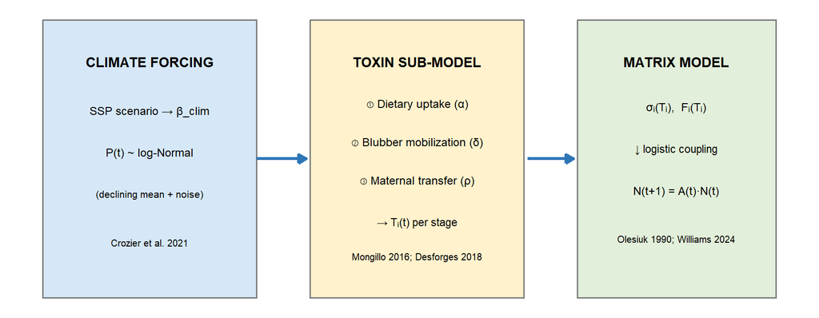

**Figure 1.** Conceptual diagram of the three-module climate–toxin–demography model. Climate forcing (left) drives stochastic annual prey availability with a secular downward trend parameterized from IPCC emissions scenarios. The toxin sub-model (center) updates stage-specific PCB burden through dietary uptake, fasting-driven blubber mobilization, and maternal transfer. Toxin loads feed into the demographic matrix (right) through logistic dose-response functions modulating survival and fecundity. Arrows show directional information flow. Simulations run for 100 years with 1,000 stochastic replicates per scenario.

# 5 Anticipated Results Figures

## 5.1 Figure 2: Population Trajectories Under Climate Scenarios

**Type:** Line plot with ribbon envelopes. **Axes:** x = year (0–100); y = total SRKW population size (N). **Data:** Median trajectory and 50%/95% envelopes from 1,000 replicates, one panel each for mobilization on/off, three colored lines per panel for baseline, SSP2-4.5, and SSP5-8.5. A horizontal dashed line marks the quasi-extinction threshold (N<sub>females</sub> = 10).

**Expected outcome:** Climate scenarios will produce increasingly depressed median trajectories, elevated quasi-extinction probabilities, and wider uncertainty envelopes — effects substantially amplified in the mobilization-on panels. This figure directly answers whether climate change alters population viability and whether the fasting-toxin pathway is a meaningful contributor beyond prey scarcity alone.

## 5.2 Figure 3: Stage-Specific PCB Trajectories and Threshold Crossing

**Type:** Faceted line plot (one panel per life stage). **Axes:** x = year (0–100); y = mean PCB concentration (mg/kg lipid weight). **Data:** Mean across replicates for each climate scenario; horizontal dashed reference lines at $T_s$ = 17 mg/kg (immune impairment) and $T_f$ = 40 mg/kg (reproductive suppression).

# 6 Example Figure: Pilot Toxin Trajectory (Single Replicate)

## 6.1 Parameters

```r
# ── Simulation settings ──────────────────────────────────────────────────────
n_years  <- 100
n_stages <- 4      # 1=calves, 2=juveniles, 3=repro females, 4=post-repro

# Initial PCB load by stage (mg/kg lipid weight)
# Approximate values from SRKW biopsy literature (Mongillo et al. 2016)
T0 <- c(5, 12, 22, 30)

# ── Prey availability ────────────────────────────────────────────────────────
P0      <- 1.0    # baseline prey index (dimensionless)
sigma_P <- 0.25   # interannual variability in prey (log-normal SD)
P_min   <- 0.60   # prey threshold below which fasting/mobilization begins

# ── Toxin process parameters ─────────────────────────────────────────────────
alpha  <- 0.05    # dietary bioaccumulation efficiency (per unit prey deficit)
delta  <- 0.06    # fasting mobilization rate: proportion of stored load released
                  # per unit prey deficit below P_min
rho    <- 0.12    # maternal transfer fraction (repro female -> calf, per birth yr)
C_prey <- 0.80    # PCB concentration in prey (mg/kg wet weight, scaled)

# ── Climate scenarios ────────────────────────────────────────────────────────
# beta_clim = annual rate of change in log(prey mean)
# Negative = declining prey over time (climate-driven Chinook loss)
scenarios <- tibble(
  label     = c("No trend (baseline)", "Moderate (SSP2-4.5)", "Severe (SSP5-8.5)"),
  beta_clim = c(0, -0.008, -0.018)
)
```

## 6.2 Simulation Function

```r
# Runs the toxin sub-model for one climate scenario.
# Loops year by year, updating toxin loads for each stage via:
#   1. Dietary uptake
#   2. Fasting-driven blubber mobilization (when prey < P_min)
#   3. Maternal transfer (repro females -> calves)

run_toxin_sim <- function(beta_clim, n_years, T0,
                          sigma_P, P0, P_min,
                          alpha, delta, rho, C_prey) {

  # Matrix to store toxin loads: rows = years (0 to n_years), cols = stages
  T_mat      <- matrix(NA, nrow = n_years + 1, ncol = length(T0))
  T_mat[1, ] <- T0   # set initial conditions

  for (yr in seq_len(n_years)) {

    # Draw prey availability for this year
    # Log-normal: mean declines at rate beta_clim with annual stochastic noise
    log_P_mean <- log(P0) + beta_clim * yr
    P_t        <- exp(rnorm(1, mean = log_P_mean, sd = sigma_P))

    T_prev <- T_mat[yr, ]   # toxin loads at start of this year

    # 1. Dietary uptake: increases when prey falls below fasting threshold
    uptake <- alpha * C_prey * max(0, P_min - P_t)

    # 2. Fasting mobilization: scarce prey -> blubber burned -> PCBs released
    #    Proportional to both prey deficit and current toxin load
    mobilize <- delta * max(0, P_min - P_t) * T_prev

    # Update all stages
    T_new <- T_prev + uptake + mobilize

    # 3. Maternal transfer: repro females (stage 3) lose rho fraction to calves
    T_new[1] <- T_new[1] + rho * T_prev[3]   # calves gain
    T_new[3] <- T_new[3] * (1 - rho)          # mothers lose

    T_mat[yr + 1, ] <- T_new
  }

  # Return as tidy tibble for plotting
  as_tibble(T_mat) %>%
    set_names(c("Calves", "Juveniles", "Repro Females", "Post-repro")) %>%
    mutate(year = 0:n_years)
}
```

## 6.3 Run All Scenarios

```r
set.seed(42)   # for reproducibility

# Run for each climate scenario and combine into one tibble
results <- scenarios %>%
  rowwise() %>%
  mutate(
    sim = list(
      run_toxin_sim(
        beta_clim = beta_clim,
        n_years   = n_years,
        T0        = T0,
        sigma_P   = sigma_P,
        P0        = P0,
        P_min     = P_min,
        alpha     = alpha,
        delta     = delta,
        rho       = rho,
        C_prey    = C_prey
      )
    )
  ) %>%
  ungroup() %>%
  unnest(sim)   # expand nested tibbles into rows

glimpse(results)
```

```
## Rows: 303
## Columns: 7
## $ label           <chr> "No trend (baseline)", "No trend (baseline)", "No tren…
## $ beta_clim       <dbl> 0, 0, 0, 0, 0, 0, 0, 0, 0, 0, 0, 0, 0, 0, 0, 0, 0, 0, …
## $ Calves          <dbl> 5.00000, 7.64000, 9.96320, 12.00762, 13.80670, 15.3899…
## $ Juveniles       <dbl> 12.00000, 12.00000, 12.00000, 12.00000, 12.00000, 12.0…
## $ `Repro Females` <dbl> 22.000000, 19.360000, 17.036800, 14.992384, 13.193298,…
## $ `Post-repro`    <dbl> 30.00000, 30.00000, 30.00000, 30.00000, 30.00000, 30.0…
## $ year            <int> 0, 1, 2, 3, 4, 5, 6, 7, 8, 9, 10, 11, 12, 13, 14, 15, …
```

## 6.4 Figure: PCB Load in Reproductive Females

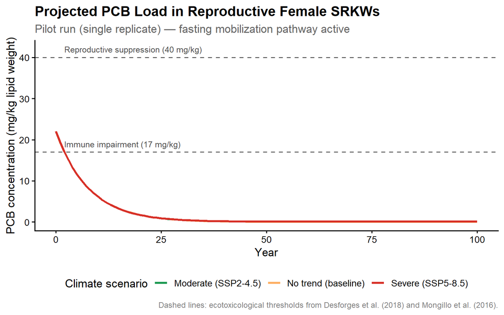

```r
# Biological threshold reference lines
thresholds <- tibble(
  yintercept = c(17, 40),
  label      = c("Immune impairment (17 mg/kg)",
                 "Reproductive suppression (40 mg/kg)")
)

ggplot(results, aes(x = year, y = `Repro Females`, colour = label)) +
  geom_line(linewidth = 1.1) +
  # Horizontal threshold lines
  geom_hline(data = thresholds,
             aes(yintercept = yintercept),
             linetype = "dashed", colour = "grey40", linewidth = 0.7) +
  # Labels for threshold lines
  geom_text(data = thresholds,
            aes(x = 2, y = yintercept + 2, label = label),
            inherit.aes = FALSE,
            hjust = 0, size = 3.3, colour = "grey30") +
  scale_colour_manual(values = c("#1a9850", "#fdae61", "#d73027")) +
  labs(
    title    = "Projected PCB Load in Reproductive Female SRKWs",
    subtitle = "Pilot run (single replicate) — fasting mobilization pathway active",
    x        = "Year",
    y        = "PCB concentration (mg/kg lipid weight)",
    colour   = "Climate scenario",
    caption  = "Dashed lines: ecotoxicological thresholds from Desforges et al. (2018) and Mongillo et al. (2016)."
  ) +
  theme_classic(base_size = 13) +
  theme(
    legend.position = "bottom",
    plot.title      = element_text(face = "bold"),
    plot.subtitle   = element_text(colour = "grey40"),
    plot.caption    = element_text(colour = "grey50", size = 9)
  )
```

## 6.5 Figure: All Four Life Stages

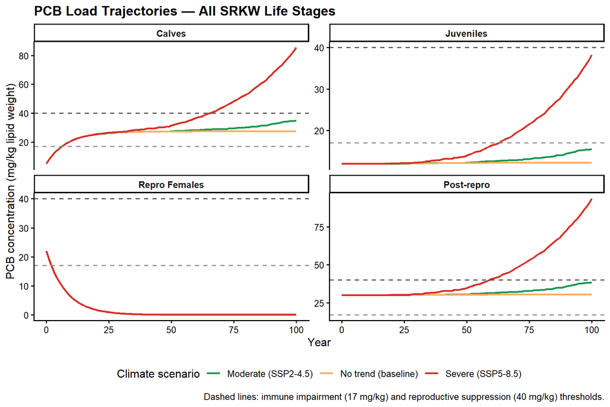

**Figure 3 (pilot).** Simulated PCB load across all four SRKW life stages under three climate scenarios. Calves reflect maternal transfer dynamics; post-reproductive individuals accumulate the highest absolute loads due to lifetime dietary uptake without reproductive offloading. Dashed lines mark immune impairment (17 mg/kg) and reproductive suppression (40 mg/kg) thresholds.

```r
# Reshape to long format for faceting
results_long <- results %>%
  pivot_longer(
    cols      = c(Calves, Juveniles, `Repro Females`, `Post-repro`),
    names_to  = "stage",
    values_to = "toxin_load"
  ) %>%
  mutate(stage = factor(stage,
    levels = c("Calves", "Juveniles", "Repro Females", "Post-repro")))

ggplot(results_long, aes(x = year, y = toxin_load, colour = label)) +
  geom_line(linewidth = 0.9) +
  geom_hline(yintercept = 17, linetype = "dashed",
             colour = "grey55", linewidth = 0.6) +
  geom_hline(yintercept = 40, linetype = "dashed",
             colour = "grey30", linewidth = 0.6) +
  facet_wrap(~stage, scales = "free_y") +
  scale_colour_manual(values = c("#1a9850", "#fdae61", "#d73027")) +
  labs(
    title   = "PCB Load Trajectories — All SRKW Life Stages",
    x       = "Year",
    y       = "PCB concentration (mg/kg lipid weight)",
    colour  = "Climate scenario",
    caption = "Dashed lines: immune impairment (17 mg/kg) and reproductive suppression (40 mg/kg) thresholds."
  ) +
  theme_classic(base_size = 12) +
  theme(
    legend.position = "bottom",
    strip.text      = element_text(face = "bold"),
    plot.title      = element_text(face = "bold")
  )
```

# 7 References

Abdul-Aziz, O. I., Mantua, N. J., & Myers, K. W. (2011). Potential climate change impacts on thermal habitats of Pacific salmon (*Oncorhynchus* spp.) in the North Pacific Ocean and adjacent seas. *Canadian Journal of Fisheries and Aquatic Sciences, 68*(10), 1660–1680. https://doi.org/10.1139/f2011-090

Atlas, W. I., Sloat, M. R., Satterthwaite, W. H., Buehrens, T. W., Parken, C. K., Moore, J. W., … & Potapova, A. (2023). Trends in Chinook salmon spawner abundance and total run size highlight linkages between life history, geography and decline. *Fish and Fisheries, 24*(4), 595–617. https://doi.org/10.1111/faf.12746

Crozier, L. G., McClure, M. M., Beechie, T., Bograd, S. J., Boughton, D. A., Carr, M., … & Zabel, R. W. (2021). Climate change threatens Chinook salmon throughout their life cycle. *Communications Biology, 4*, 222. https://doi.org/10.1038/s42003-021-01734-w

Desforges, J.-P., Hall, A., McConnell, B., Rosing-Asvid, A., Barber, J. L., Brownlow, A., … & Dietz, R. (2018). Predicting global killer whale population collapse from PCB pollution. *Science, 361*(6409), 1373–1376. https://doi.org/10.1126/science.aat1953

Ford, J. K. B., Ellis, G. M., Olesiuk, P. F., & Balcomb, K. C. (2010). Linking killer whale survival and prey abundance: food limitation in the oceans’ apex predator? *Biology Letters, 6*(1), 139–142. https://doi.org/10.1098/rsbl.2009.0468

Marine Mammal Commission. (2020). *Southern Resident Killer Whale*. U.S. Marine Mammal Commission Species Overview. https://www.mmc.gov/priority-topics/species-of-concern/southern-resident-killer-whale/

Mongillo, T. M., Ylitalo, G. M., Rhodes, L. D., O’Neill, S. M., Noren, D. P., & Hanson, M. B. (2016). *Exposure to a mixture of toxic chemicals: implications for the health of endangered Southern Resident killer whales* (NOAA Technical Memorandum NMFS-NWFSC-135). U.S. Department of Commerce. https://doi.org/10.7289/V5/TM-NWFSC-135

Olesiuk, P. F., Bigg, M. A., & Ellis, G. M. (1990). Life history and population dynamics of resident killer whales (*Orcinus orca*) in the coastal waters of British Columbia and Washington State. *Report of the International Whaling Commission, Special Issue 12*, 209–243.

Ward, E. J., Holmes, E. E., & Balcomb, K. C. (2009). Quantifying the effects of prey availability on killer whale (*Orcinus orca*) reproductive success. *Journal of Applied Ecology, 46*(3), 632–640. https://doi.org/10.1111/j.1365-2664.2009.01647.x

Williams, R., Lacy, R. C., Ashe, E., Barrett-Lennard, L., Brown, T. M., Gaydos, J. K., … & Paquet, P. (2024). Warning sign of an accelerating decline in critically endangered killer whales (*Orcinus orca*). *Communications Earth & Environment, 5*, 173. https://doi.org/10.1038/s43247-024-01327-5